# Chapter 4 - The grammar of graphics and the `ggplot2` package

```r
# ggplot(longley, aes(x = Year)) +
#     geom_point(aes(y = Unemployed)) +
#     geom_point(aes(y = Armed.Forces), color = "blue") +
#     geom_line(aes(y = Unemployed)) +
#     geom_line(aes(y = Armed.Forces), color = "blue")
```

The two measures *Unemployment* and *Armed.Forces* are two different measures we have per year and that we can plot together. The data is not reflecting this as something we can compute on. We can split the two measures into subplots insted of plotting them in the same frame. But a better solution is to reformat the data frame so we have one column telling us whether an observation is Unemployment or Armed.Forces and another using the values and then setting the color according to the first column and the y-axis according to the other. You can do this with the `gather()` function from `tidyr` package:

*This chunk of code is for watching the result of the tidying before passing to the one line plotting with the tidying included:*

```r
longley %>%
    gather(key = Status, value = Measure, Unemployed, Armed.Forces) %>%
    select(Status,Measure,Year) %>%
    head(10) %>% kable
```

| Status | Measure | Year |
| --- | --- | --- |
| Unemployed | 235.6 | 1947 |
| Unemployed | 232.5 | 1948 |
| Unemployed | 368.2 | 1949 |
| Unemployed | 335.1 | 1950 |
| Unemployed | 209.9 | 1951 |
| Unemployed | 193.2 | 1952 |
| Unemployed | 187.0 | 1953 |
| Unemployed | 357.8 | 1954 |
| Unemployed | 290.4 | 1955 |
| Unemployed | 282.2 | 1956 |

Tidying and plotting all together:

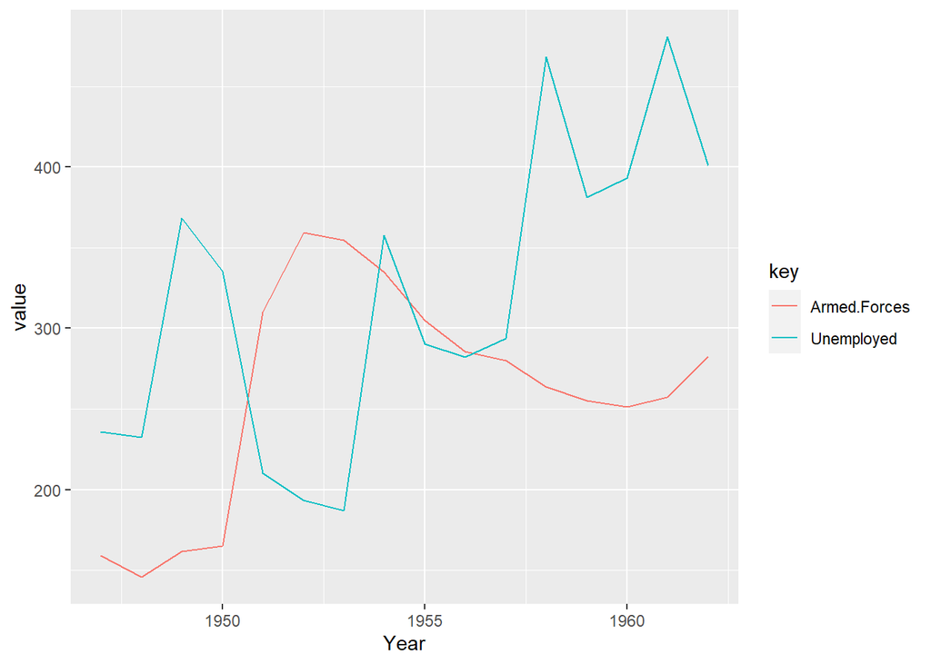

```r
longley %>% gather(key,value, Unemployed, Armed.Forces) %>%
    ggplot(aes(x = Year, y = value, color = key)) + geom_line()
```

If you want the two values in different facets, we can specify this instead of setting colors:

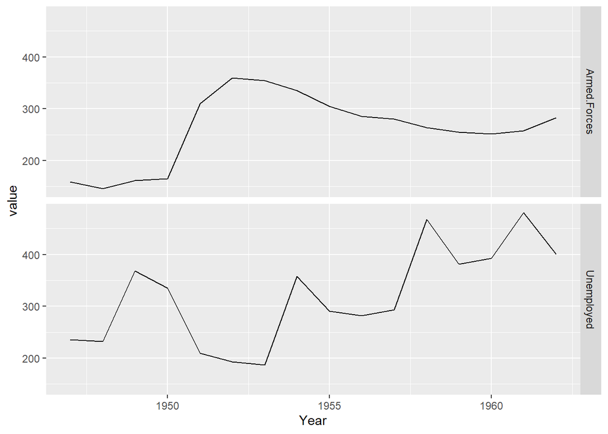

```r
# longley %>% gather(key, value, Unemployed, Armed.Forces) %>%
#     ggplot(aes(x = Year, y = value)) + geom_line() +
#     facet_grid(key ~ .)

longley %>% pivot_longer(c(Unemployed, Armed.Forces), names_to = "key", values_to = "value") %>%
    ggplot(aes(x = Year, y = value)) + geom_line() +
    facet_grid(key ~ .)
```

### Facets

*Facets* are subplots showing different subset of the data. You can specify facects using one of two functions, `facet_grid()` creates facets from a fomrula `rows ~columns` adding `facet_wrap()` creates facets form the formula `~ variables`.

By deafult, `ggplot2` will try to put values on the same axes when you create facets using `facet_grid()`.

In the previous example, Armed.Forces values a re shown on the same x- and y-axis as Unemployment even though the y-values are not covering the same range. The parameter `scales` can be used to change this. Facets within a column will always have the same x-axis, however, and facects within a row will have the same y-axis.

#### `pivot_longer()` is the new recommended function instead of `gather()`.

```r
#iris %>% gather(Measurement, Value, -Species) %>% head(10) %>% kable
# Instead
iris %>% pivot_longer(c(-Species), names_to = "Key", values_to = "Value") %>% head(10) %>% kable
```

| Species | Key | Value |
| --- | --- | --- |
| setosa | Sepal.Length | 5.1 |
| setosa | Sepal.Width | 3.5 |
| setosa | Petal.Length | 1.4 |
| setosa | Petal.Width | 0.2 |
| setosa | Sepal.Length | 4.9 |
| setosa | Sepal.Width | 3.0 |
| setosa | Petal.Length | 1.4 |
| setosa | Petal.Width | 0.2 |
| setosa | Sepal.Length | 4.7 |
| setosa | Sepal.Width | 3.2 |

Plotting the four measurements for each species i diffent facets with the *iris* data:

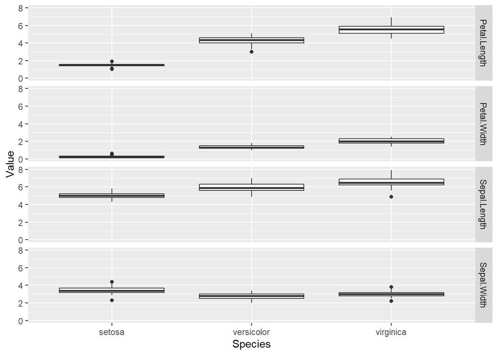

```r
iris %>% pivot_longer(c(-Species), names_to = "Measurement", values_to = "Value") %>%
    ggplot(aes(x = Species, y = Value)) +
    geom_boxplot() +
    facet_grid(Measurement ~ .)
```

Fixing the scale:

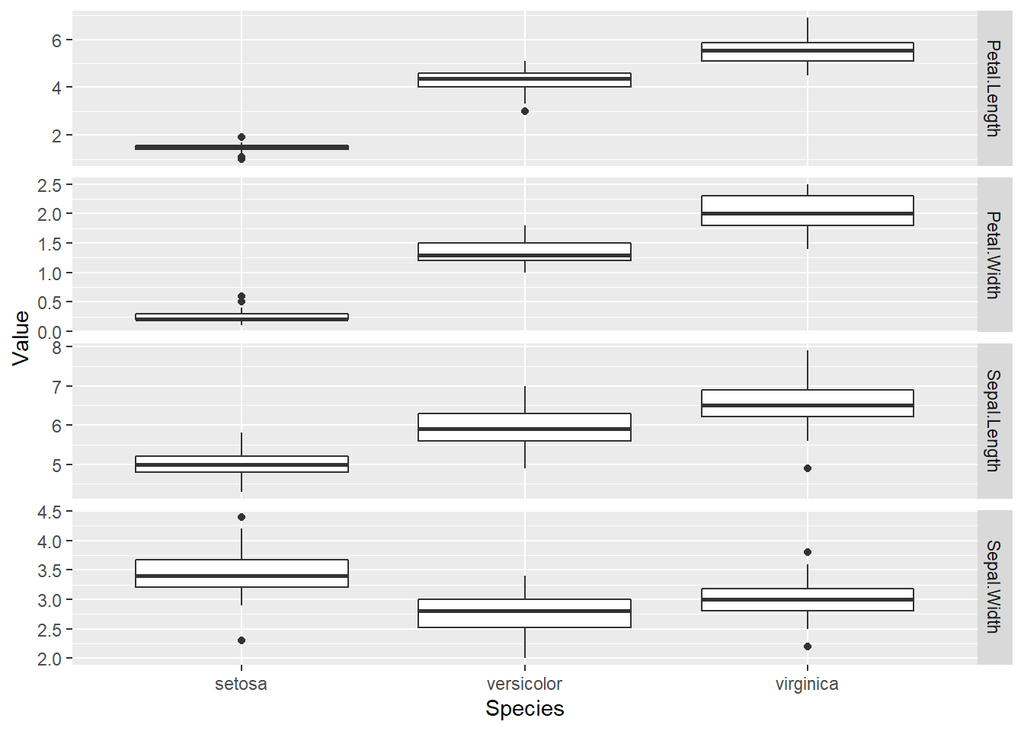

```r
iris %>% pivot_longer(c(-Species), names_to = "Measurement",  values_to = "Value") %>%
    ggplot(aes(x = Species, y = Value)) +
    geom_boxplot() +
    facet_grid(Measurement ~ ., scale = "free_y")
```

By default, all the facets will have the same size. You can modify this using `space` variable. This is mainy useful for categorical values if one facet has many more levels than another.

The labels used for facets are taken from the factors in the variables used to construct the facet.

To modify the labels you can use `labeller` paremeter to `facet_grid()`.

This paremeter takes a function (`labeller()`) as an argument that is responsible for constructing labels. You can give `labeller()`a named argument and specify a factor to make labels.

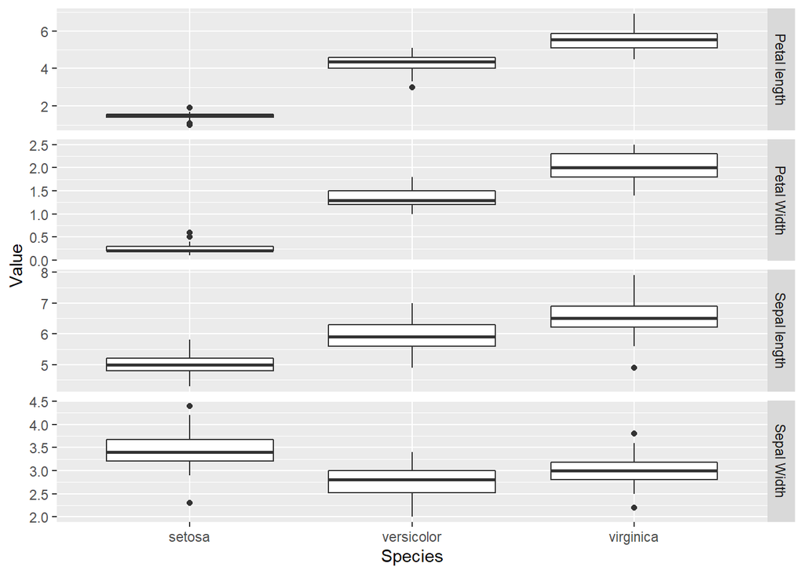

```r
label_map <- c(Petal.Width = "Petal Width",
               Petal.Length = "Petal length",
               Sepal.Width = "Sepal Width",
               Sepal.Length = "Sepal length")

iris %>% pivot_longer(c(-Species), names_to = "Measurement", values_to = "Value") %>%
    ggplot(aes(x = Species, y = Value)) +
    geom_boxplot() +
    facet_grid(Measurement ~ ., scale = "free_y",
               labeller = labeller(Measurement = label_map))
```

### Scaling

The geometries tell `ggplot2` how you want your data mapped to visual components, like points or densities, and scales tell `ggplot2` gow dimensions should be visualized. The simplest scales are x- and y-axes, where values are mapped to positions, but scales also apply to colors.

The simplest wat to use `scales` is to put labels on the axes, you can also do this using the `xlab()` and `ylab()` functions, however in this example you see a different use of scales:

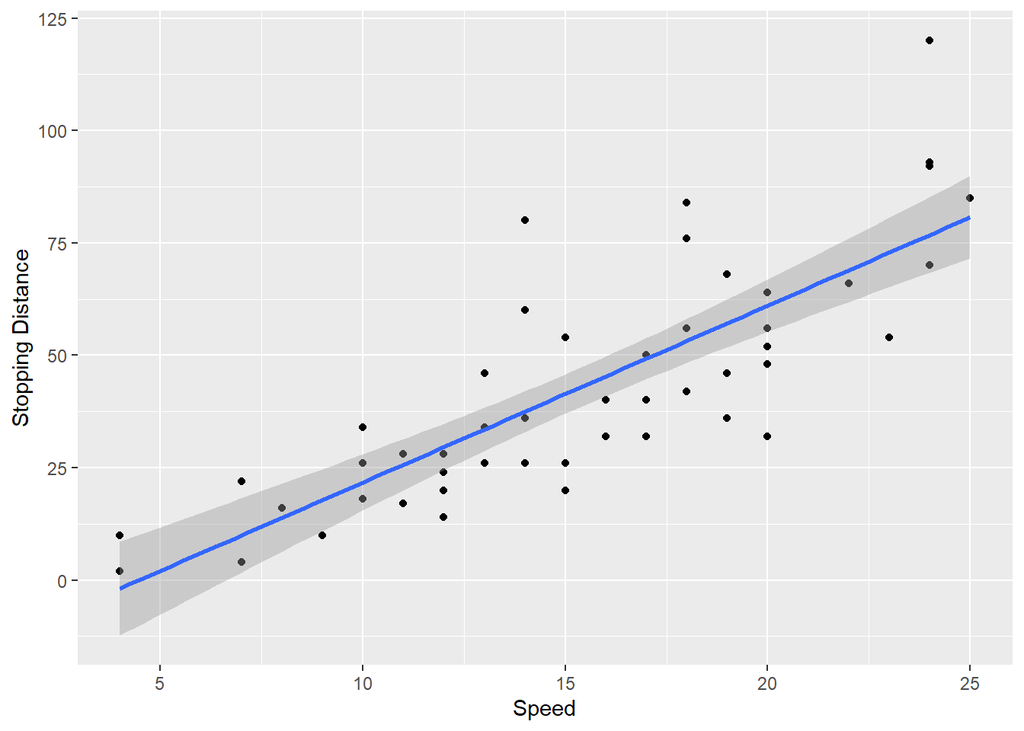

```r
cars %>% ggplot(aes(x = speed, y = dist)) +
    geom_point() + geom_smooth(method = "lm") +
    scale_x_continuous("Speed") +
    scale_y_continuous("Stopping Distance")
```

Both x- and y-axis are showing a continous value, o we scale like that and give the scale a name as the parameter.

In general, you can use `scale_x/y_continuous()` functions to control the axis graphics.

For example, to set the breakpoints, if you want to plot the *longley* data with a tickmark for every year instead of every five years:

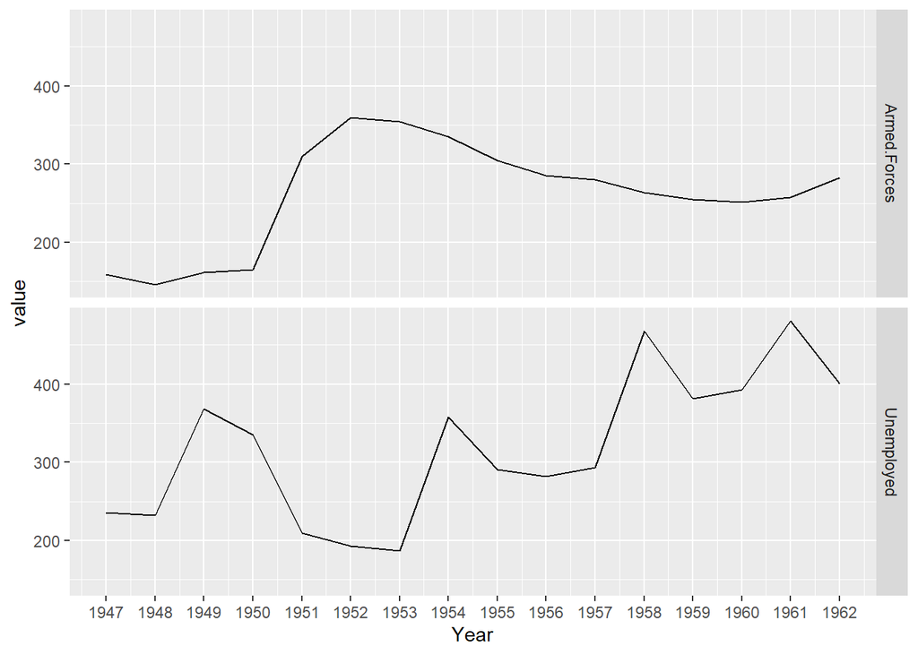

```r
longley %>% pivot_longer(c(Unemployed, Armed.Forces), names_to = "key", values_to = "value") %>%
    ggplot(aes(x = Year, y = value)) + geom_line() +
    scale_x_continuous(breaks = 1947:1962) +
    facet_grid(key ~ .)
```

Scales are also a way to transform data shown on an axis. If you want to log-transform the x- or y-axis, you can use the `scale_x/y_log10()` functions, for instance. This usually leads to a nicer plot since the plotting code then knows that you want to show the data on a log scale rather than showing transformed data on a linear scale.

To reverse an axis use `scale_x/y_reverse()`. This is better than reversing the data mapped in the aesthetic.

[output not shown]

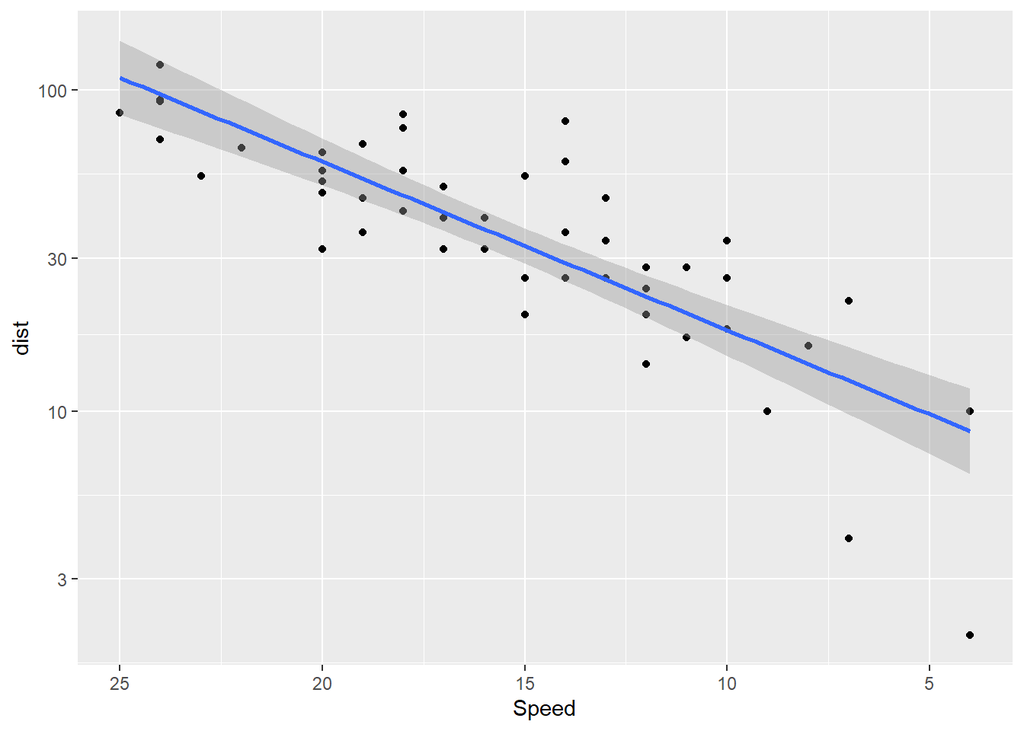

```r
cars %>% ggplot(aes(x = speed, y = dist)) +
geom_point() + geom_smooth(method = "lm") +
scale_x_reverse("Speed") +
scale_y_continuous("Stoppping Distance") +
scale_y_log10()
```

Neither axis has to be continuous. If you map a factor to x or y in the aesthetics, yoy get a discrete axis.

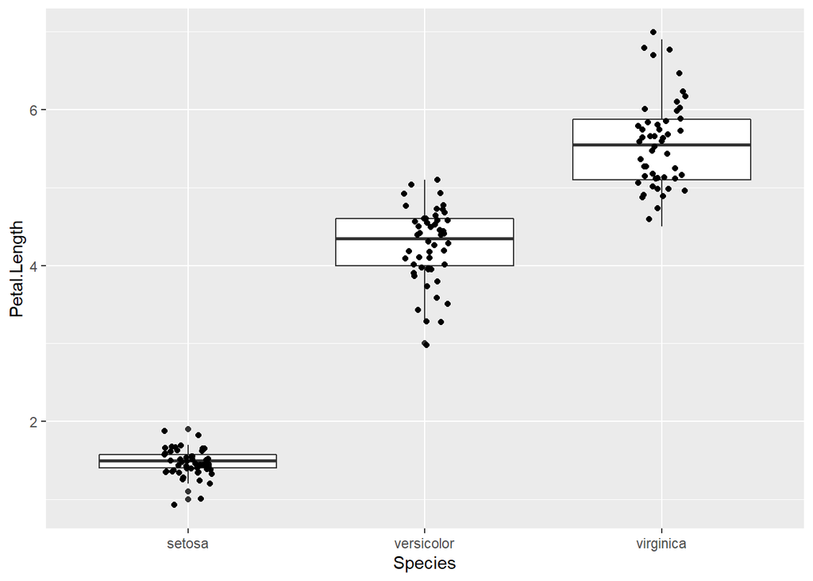

```r
iris %>% ggplot(aes(x = Species, y = Petal.Length)) +
    geom_boxplot() + geom_jitter(width = 0.1, height = 0.1)
```

If you want to modify the x-axis, you need to use `scale_x_discrete()` instead of `scale_x_continuous()`.

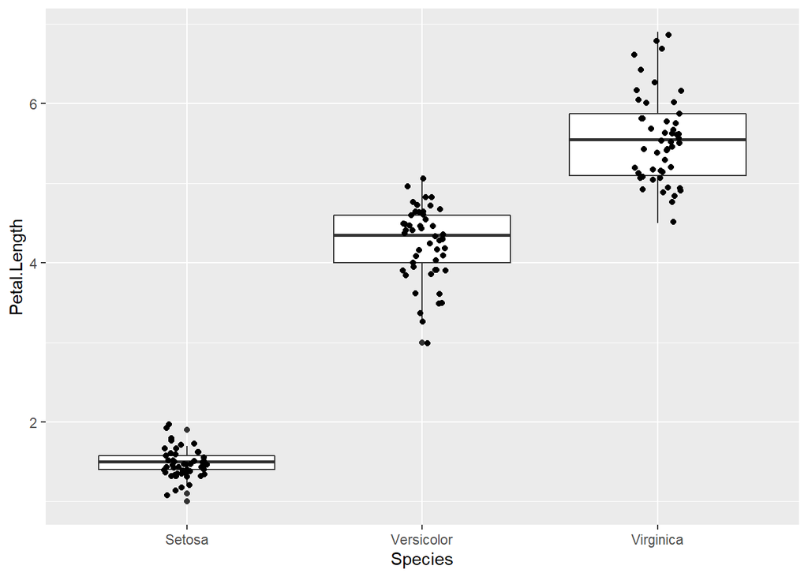

```r
iris %>% ggplot(aes(x = Species, y = Petal.Length)) +
    geom_boxplot() + geom_jitter(width = 0.1, height = 0.1) +
    scale_x_discrete(label = c("setosa" = "Setosa",
                               "versicolor" = "Versicolor",
                               "virginica" = "Virginica"))
```

You can use various `scale_color_` functions to control the color of lines and points, and you use `scale_fill_` function to control the color fo filled areas.

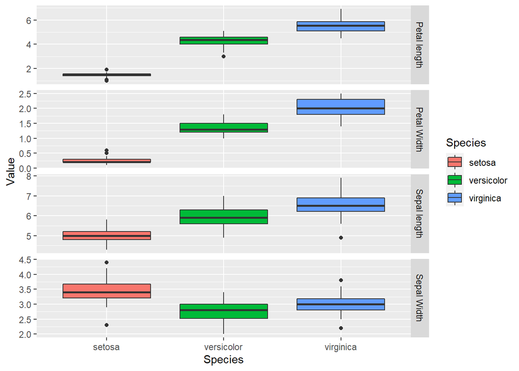

```r
iris %>% pivot_longer(c(-Species), names_to = "Measurement", values_to = "Value") %>%
    ggplot(aes(x = Species, y = Value, fill = Species)) +
    geom_boxplot() +
    facet_grid(Measurement ~ ., scale = "free_y",
               labeller = labeller(Measurement = label_map))
```

There are two classes, as there are for axes-discrete and continuous. The Species variable in *iris* is discrete. To modify the color you need one of the functions. The simplest is just to give a color per species explicitly. You can do that with the `scale_fill_manual()` function:

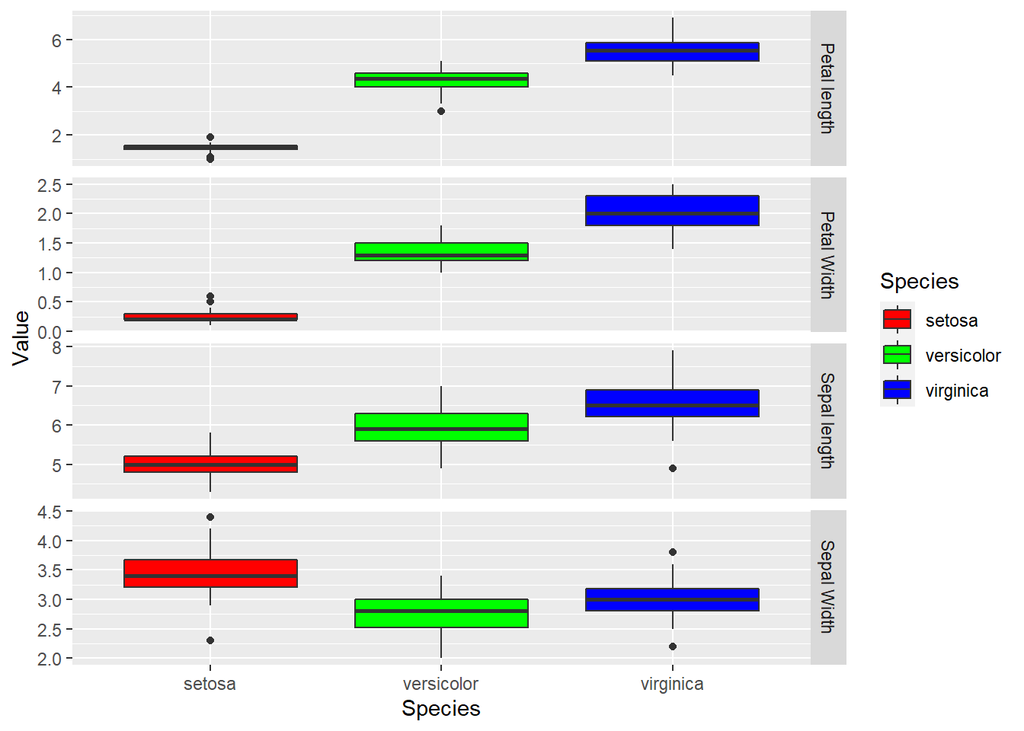

```r
iris %>% pivot_longer(c(-Species), names_to = "Measurement", values_to = "Value") %>%
    ggplot(aes(x = Species, y = Value, fill = Species)) +
    geom_boxplot() +
    scale_fill_manual(values = c("red", "green", "blue")) +
    facet_grid(Measurement ~ ., scale = "free_y",
               labeller = labeller(Measurement = label_map))
```

Unless you have a good feeling for how colors work together and which combinations can be problematic for color-blind, it is better to use one of the “brewer” choices. The are methods for constructing good combinations of colors, and you can use them with the `scale_fill_brewer()` function:

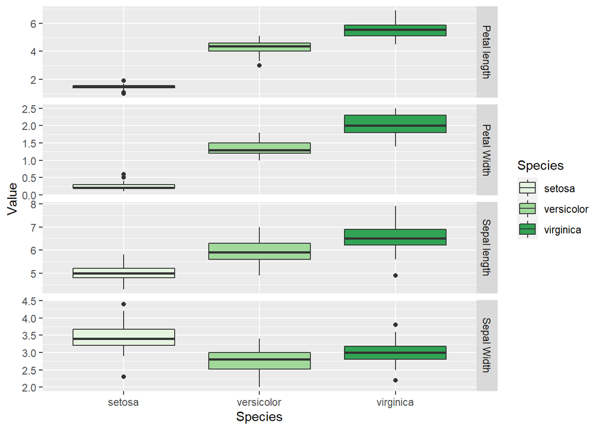

```r
iris %>% pivot_longer(c(-Species), names_to = "Measurement", values_to = "Value") %>%
    ggplot(aes(x = Species, y = Value, fill = Species)) +
    geom_boxplot() +
    scale_fill_brewer(palette = "Greens") +
    facet_grid(Measurement ~ ., scale = "free_y",
               labeller = labeller(Measurement = label_map))
```

### Themes and ther Graphics Transformations

To set a default theme:

```r
theme_set(theme_bw())
```

Look for functions that start with `theme_`, you can add them to the plot using + as you would any other `ggplot2` modification.

You can change coordinate systems using various `coord_` functions, the simplest is just flipping x and y with the `coord_flip()`.

You can control the placement of facet labels using the switch option to face_grid(). Giving the `swtich` parameter the value y will switch the location of that label.

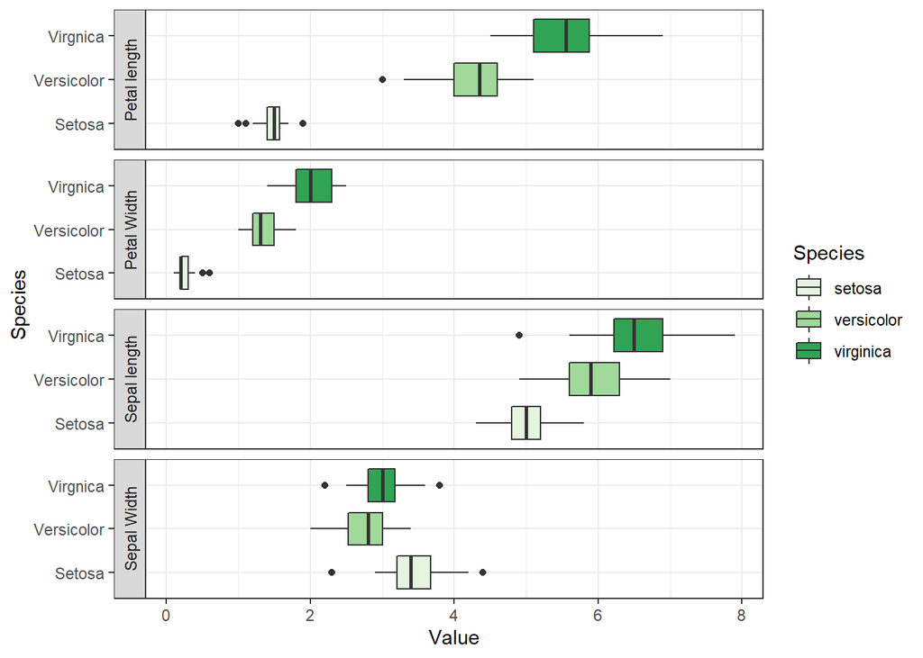

```r
iris %>% pivot_longer(c(-Species), names_to = "Measurement", values_to = "Value") %>%
    ggplot(aes(x = Species, y = Value, fill = Species)) +
    geom_boxplot() +
    scale_x_discrete(labels = c("setosa" = "Setosa",
                                "versicolor" = "Versicolor",
                                "virginica" = "Virgnica")) +
    scale_fill_brewer(palette ="Greens") +
    facet_grid(Measurement ~ ., switch = "y",
               labeller = labeller(Measurement = label_map)) +
    coord_flip()
```

To change the labels color background you can use `theme(strip.background = element_blank())`. We can also move the legend label using a theme modification such as `theme(legend.position = "top")`.

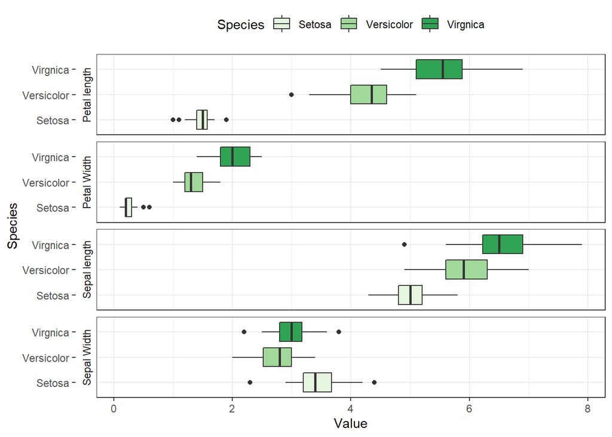

```r
label_map <- c(Petal.Width = "Petal Width",
               Petal.Length = "Petal length",
               Sepal.Width = "Sepal Width",
               Sepal.Length = "Sepal length")

species_map <- c("setosa" = "Setosa",
                "versicolor" = "Versicolor",
                "virginica" = "Virgnica")

iris %>% pivot_longer(c(-Species), names_to = "Measurement", values_to = "Value") %>%
    ggplot(aes(x = Species, y = Value, fill = Species)) +
    geom_boxplot() +
    scale_x_discrete(labels = species_map) +
    scale_fill_brewer(palette ="Greens", labels = species_map) +
    facet_grid(Measurement ~ ., switch = "y",
               labeller = labeller(Measurement = label_map)) +
    coord_flip() +
    theme(strip.background = element_blank()) +
    theme(legend.position = "top")
```

### Figures with multiple plots

You use facets when you want to plot different subsets of the data. But esentially is the same plot.

The `ggplot2` package doesn’t support combining multiple plots, but in cam be achieved using the underlying graphics system, `grid` high-level functions.

You can get this from the `gridExtra` package.

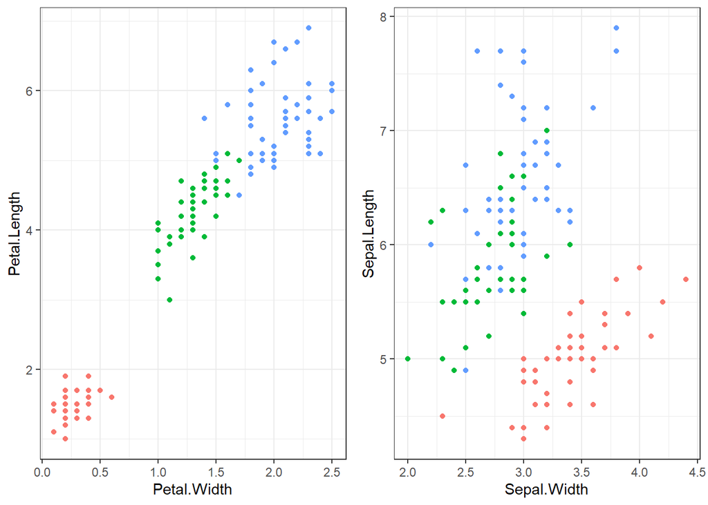

```r
petal <-  iris %>% ggplot() +
    geom_point(aes(x = Petal.Width, y = Petal.Length, color = Species)) +
    theme(legend.position = "none")

sepal <- iris %>% ggplot() +
    geom_point(aes(x = Sepal.Width, y = Sepal.Length, color  = Species)) +
    theme(legend.position = "none")

library(gridExtra)
grid.arrange(petal, sepal, ncol = 2)
```

Another aproach is to use `plot_grid()` function from cowplot package. This package redefines the default `ggplot2` package. *You can use `theme_set()` function to change it back if you don’t like the theme that cowplot provides.

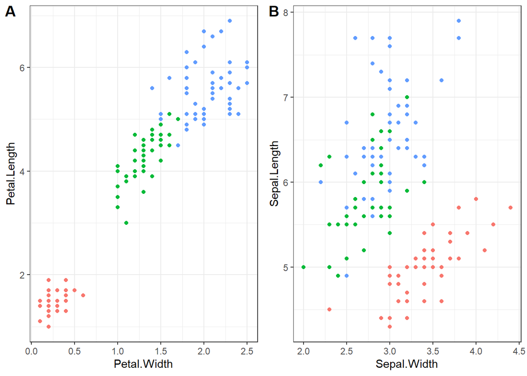

```r
library(cowplot)

plot_grid(petal, sepal, labels = c("A", "B"))
```